# Midterm Assignemnt, ME314 2019

## Question 2:

You will need to load the core library for the course textbook and any other libraries you find suitable to answer the question:

This question should be answered using the `Weekly` data set, which is part of the **ISLR** package. This data contains 1,089 weekly stock returns for 21 years, from the beginning of 1990 to the end of 2010.

#### 1. Perform exploratory data analysis of the `Weekly` data (produce some numerical and graphical summaries). Discuss any patterns that emerge.

```r
data(Weekly)

attach(Weekly)

sum(is.na(Weekly))      # = 0
```

```
## [1] 0
```

```r
summary(dplyr::select_if(Weekly, is.numeric))
```

```
##       Year           Lag1               Lag2               Lag3
##  Min.   :1990   Min.   :-18.1950   Min.   :-18.1950   Min.   :-18.1950
##  1st Qu.:1995   1st Qu.: -1.1540   1st Qu.: -1.1540   1st Qu.: -1.1580
##  Median :2000   Median :  0.2410   Median :  0.2410   Median :  0.2410
##  Mean   :2000   Mean   :  0.1506   Mean   :  0.1511   Mean   :  0.1472
##  3rd Qu.:2005   3rd Qu.:  1.4050   3rd Qu.:  1.4090   3rd Qu.:  1.4090
##  Max.   :2010   Max.   : 12.0260   Max.   : 12.0260   Max.   : 12.0260
##       Lag4               Lag5              Volume
##  Min.   :-18.1950   Min.   :-18.1950   Min.   :0.08747
##  1st Qu.: -1.1580   1st Qu.: -1.1660   1st Qu.:0.33202
##  Median :  0.2380   Median :  0.2340   Median :1.00268
##  Mean   :  0.1458   Mean   :  0.1399   Mean   :1.57462
##  3rd Qu.:  1.4090   3rd Qu.:  1.4050   3rd Qu.:2.05373
##  Max.   : 12.0260   Max.   : 12.0260   Max.   :9.32821
##      Today
##  Min.   :-18.1950
##  1st Qu.: -1.1540
##  Median :  0.2410
##  Mean   :  0.1499
##  3rd Qu.:  1.4050
##  Max.   : 12.0260
```

```r
# check how many weeks are included in each year
count_by_years <- group_by(Weekly, Year) %>%
                                    summarise(n = n())

count_by_years
```

```
## # A tibble: 21 x 2
##     Year     n
##    <dbl> <int>
##  1  1990    47
##  2  1991    52
##  3  1992    52
##  4  1993    52
##  5  1994    52
##  6  1995    52
##  7  1996    53
##  8  1997    52
##  9  1998    52
## 10  1999    52
## # … with 11 more rows
```

```r
# ---- explore Lagged returns
# generate a correlation matrix between the lag variables
corr.mat <- dplyr::select(Weekly, -Direction) %>%
          dplyr::mutate(as.numeric(Direction)) %>%
                      cor() %>%
                      round(3)
corr.mat
```

```
##                         Year   Lag1   Lag2   Lag3   Lag4   Lag5 Volume
## Year                   1.000 -0.032 -0.033 -0.030 -0.031 -0.031  0.842
## Lag1                  -0.032  1.000 -0.075  0.059 -0.071 -0.008 -0.065
## Lag2                  -0.033 -0.075  1.000 -0.076  0.058 -0.072 -0.086
## Lag3                  -0.030  0.059 -0.076  1.000 -0.075  0.061 -0.069
## Lag4                  -0.031 -0.071  0.058 -0.075  1.000 -0.076 -0.061
## Lag5                  -0.031 -0.008 -0.072  0.061 -0.076  1.000 -0.059
## Volume                 0.842 -0.065 -0.086 -0.069 -0.061 -0.059  1.000
## Today                 -0.032 -0.075  0.059 -0.071 -0.008  0.011 -0.033
## as.numeric(Direction) -0.022 -0.050  0.073 -0.023 -0.021 -0.018 -0.018
##                        Today as.numeric(Direction)
## Year                  -0.032                -0.022
## Lag1                  -0.075                -0.050
## Lag2                   0.059                 0.073
## Lag3                  -0.071                -0.023
## Lag4                  -0.008                -0.021
## Lag5                   0.011                -0.018
## Volume                -0.033                -0.018
## Today                  1.000                 0.720
## as.numeric(Direction)  0.720                 1.000
```

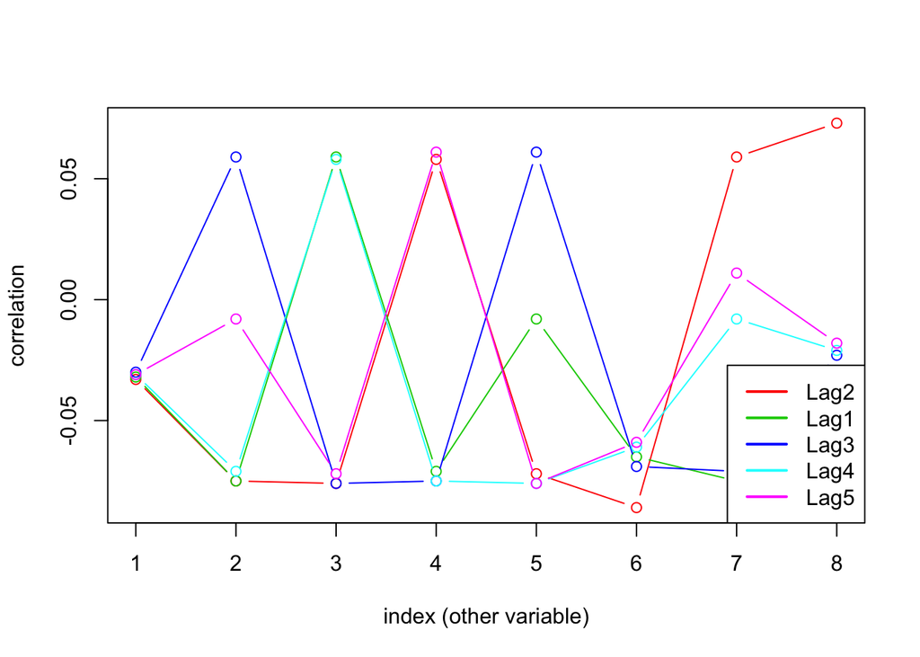

```r
# plot the correlation between the lag variables
plot(corr.mat[which(rownames(corr.mat)=="Lag2"), -which(rownames(corr.mat)=="Lag2")],
              type="b", col=2,xlab="index (other variable)", ylab="correlation")
lines(corr.mat[which(rownames(corr.mat)=="Lag1"),-which(rownames(corr.mat)=="Lag1")],
              type="b", col=3, ylab="")
lines(corr.mat[which(rownames(corr.mat)=="Lag3"),-which(rownames(corr.mat)=="Lag3")],
              type="b", col=4, ylab="")
lines(corr.mat[which(rownames(corr.mat)=="Lag4"),-which(rownames(corr.mat)=="Lag4")],
              type="b", col=5, ylab="")
lines(corr.mat[which(rownames(corr.mat)=="Lag5"),-which(rownames(corr.mat)=="Lag5")],
              type="b", col=6)
legend("bottomright", legend = c("Lag2", "Lag1", "Lag3", "Lag4", "Lag5"),
       col = 2:6, lwd = 2)
```

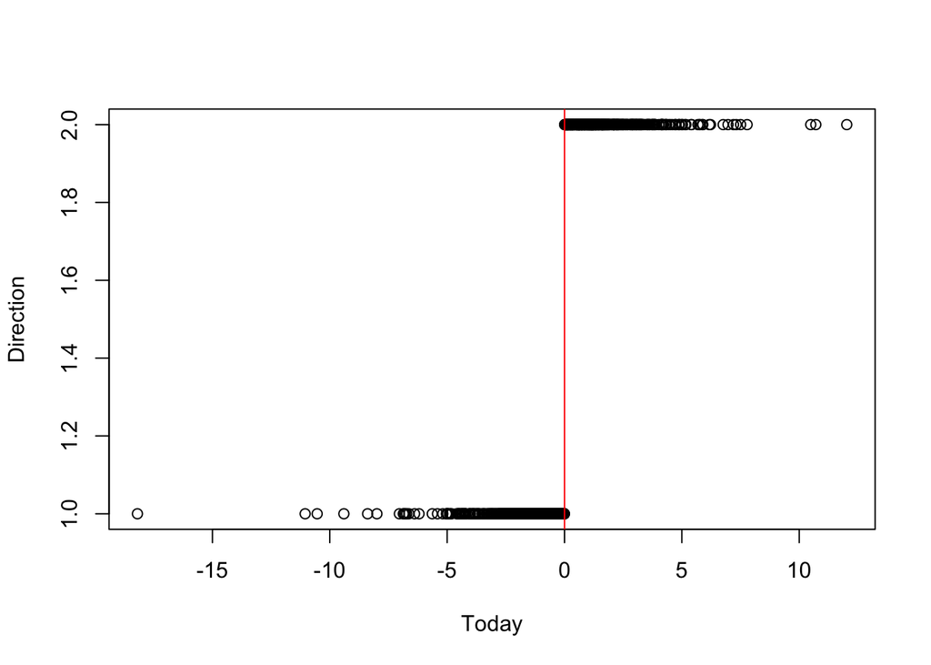

```r
# ---- explore Direction

plot(Today, Direction)
abline( v = 0 , col = "red")
```

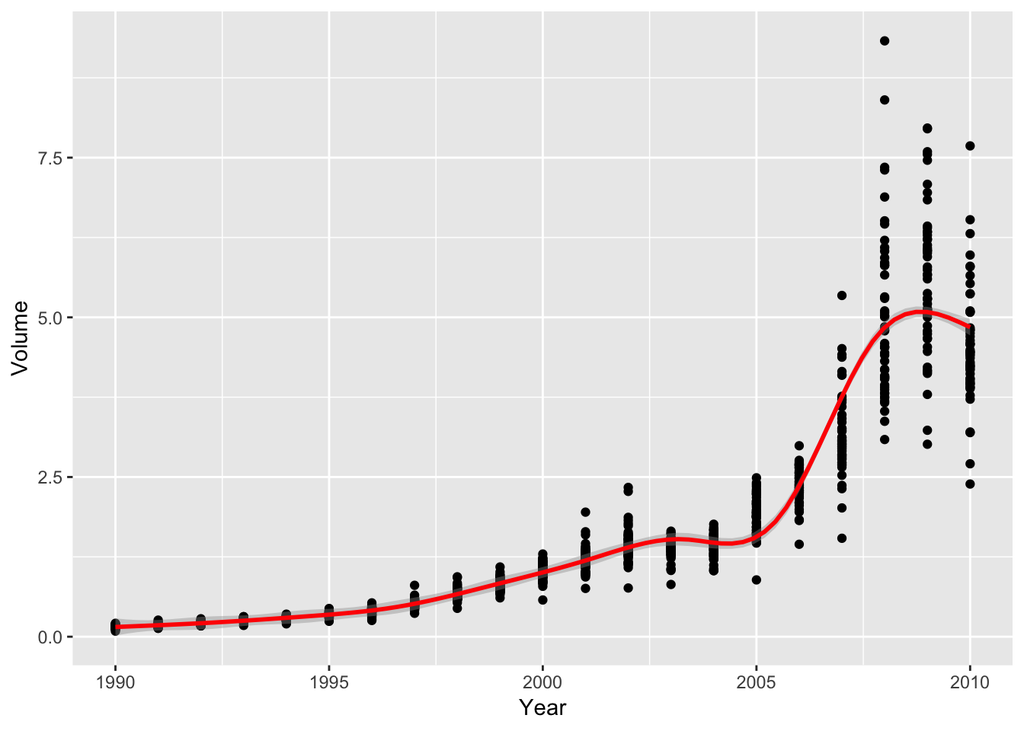

```r
ggplot(data = Weekly)  +
  geom_point(mapping = aes(x = Year, y = Volume)) +
  geom_smooth(mapping = aes(x = Year, y = Volume), col="red")
```

```r
print(mean(as.numeric(Direction)))
```

```
## [1] 1.555556
```